# Machine Learning for Crime Prevention in Chicago

Chicago is an international city, and is a hub for culture, finance, telecom. The city provides a great experience to visitors in the form of natural beauty by virtue of being located along the shores of Lake Michigan, and with landmarks such as Magnificent Mile, Millennium Park, Grant Park, Navy Pier, Art Institute of Chicago, Willis Tower (once the tallest building in the world). The combination of both commerce and tourism made Chicago the second most visited city in America with over 58 million visitors in 2018.

However, the last few years Chicago gained a bad reputation with the crime numbers which are all over the news. To make it worse, most crimes happen during summer when most people plan their vacations to Chicago area. Any approach to predict where and when the crimes happen will be beneficial to the police force with their deployments to potentially stop crimes from happening. Besides the police, Chicago has a lot of community and church organizers who can potentially try to focus their efforts to stop crimes from happening if they knew the locations and times

The goal of this project is to use machine learning techniques to predict when and where the crimes will occur. Since it's virtually impossible to predict the number of crimes on a given day, a supervised binary classification model was used to predict if a certain group of crimes will happen on a given day and in a certain location.

The group of crimes chosen was homicides, weapons violations, robbery and assault since they are closely related to each other. The chicago crime dataset from Kaggle was used, the data contains all the crimes that happened from 2015. In order to train and test the model, the data was separated into violent and non-violent crimes and assigned labels 0 and 1

### Data Load and Analysis

The chicago crime data set is quite large. This file needs to be downloaded directly from https://www.kaggle.com/armyaviator/chicago-crime-dataset-2001-present

```python
import pandas as pd

data = pd.read_csv('Crimes_-_2001_to_present.csv')

#data = data.loc[((data['Year']).isin([2017,2018]))]

data = data.loc[((data['Location Description']).isin(['STREET', 'SIDEWALK', 'ALLEY','YARD','CHA GROUNDS','CHA PARKING LOT', 'CHA PARKING LOT/GROUNDS']))]
data = data.loc[((data['Domestic']) == False)]
```

```python
data.info()
```

```
<class 'pandas.core.frame.DataFrame'>
Int64Index: 315732 entries, 0 to 1048572
Data columns (total 30 columns):
ID                            315732 non-null int64
Case Number                   315732 non-null object
Date                          315732 non-null object
Block                         315732 non-null object
IUCR                          315732 non-null object
Primary Type                  315732 non-null object
Description                   315732 non-null object
Location Description          315732 non-null object
Arrest                        315732 non-null bool
Domestic                      315732 non-null bool
Beat                          315732 non-null int64
District                      315732 non-null float64
Ward                          315730 non-null float64
Community Area                315731 non-null float64
FBI Code                      315732 non-null object
X Coordinate                  313719 non-null float64
Y Coordinate                  313719 non-null float64
Year                          315732 non-null int64
Updated On                    315732 non-null object
Latitude                      313719 non-null float64
Longitude                     313719 non-null float64
Location                      313719 non-null object
Historical Wards 2003-2015    313118 non-null float64
Zip Codes                     313719 non-null float64
Community Areas               313243 non-null float64
Census Tracts                 313276 non-null float64
Wards                         313248 non-null float64
Boundaries - ZIP Codes        313246 non-null float64
Police Districts              313257 non-null float64
Police Beats                  313257 non-null float64
dtypes: bool(2), float64(15), int64(3), object(10)
memory usage: 70.5+ MB
```

```python
data = data.dropna()
data.head()
```

|  | ID | Case Number | Date | Block | IUCR | Primary Type | Description | Location Description | Arrest | Domestic | ... | Longitude | Location | Historical Wards 2003-2015 | Zip Codes | Community Areas | Census Tracts | Wards | Boundaries - ZIP Codes | Police Districts | Police Beats |
| --- | --- | --- | --- | --- | --- | --- | --- | --- | --- | --- | --- | --- | --- | --- | --- | --- | --- | --- | --- | --- | --- |
| 164 | 24553 | JC274276 | 5/22/2019 19:39 | 080XX S EMERALD AVE | 110 | HOMICIDE | FIRST DEGREE MURDER | STREET | False | False | ... | -87.642752 | (41.748344547, -87.64275238) | 18.0 | 21554.0 | 70.0 | 529.0 | 13.0 | 59.0 | 20.0 | 229.0 |
| 1236 | 11694416 | JC271932 | 5/21/2019 9:55 | 072XX S CLAREMONT AVE | 031A | ROBBERY | ARMED: HANDGUN | SIDEWALK | False | False | ... | -87.681857 | (41.762442648, -87.681857379) | 6.0 | 22257.0 | 64.0 | 333.0 | 30.0 | 23.0 | 13.0 | 207.0 |
| 1237 | 11694353 | JC271942 | 5/21/2019 9:50 | 043XX W FERDINAND ST | 810 | THEFT | OVER $500 | STREET | False | False | ... | -87.734260 | (41.889730129, -87.734259715) | 11.0 | 21572.0 | 24.0 | 99.0 | 23.0 | 30.0 | 16.0 | 68.0 |
| 1282 | 11694402 | JC271866 | 5/21/2019 8:20 | 052XX S PULASKI RD | 460 | BATTERY | SIMPLE | SIDEWALK | True | False | ... | -87.723293 | (41.797841025, -87.7232926) | 35.0 | 22248.0 | 60.0 | 793.0 | 6.0 | 56.0 | 13.0 | 129.0 |
| 1284 | 11694299 | JC271869 | 5/21/2019 8:20 | 010XX N MONTICELLO AVE | 1811 | NARCOTICS | POSS: CANNABIS 30GMS OR LESS | SIDEWALK | True | False | ... | -87.717674 | (41.899683587, -87.717673947) | 41.0 | 4299.0 | 24.0 | 456.0 | 46.0 | 5.0 | 16.0 | 66.0 |

5 rows × 30 columns

There are around 30 different kinds of crimes, we are grouping Homicide, Weapons Violation (people carrying illegal weapons), Robbery (includes mugging), Assault as violent group and labeling them with 1. The other crimes will be labeled as 0

```python
crimes = data['Primary Type'].sort_values().unique()
display(crimes)
```

```
array(['ARSON', 'ASSAULT', 'BATTERY', 'BURGLARY',
       'CONCEALED CARRY LICENSE VIOLATION', 'CRIM SEXUAL ASSAULT',
       'CRIMINAL DAMAGE', 'CRIMINAL TRESPASS', 'DECEPTIVE PRACTICE',
       'GAMBLING', 'HOMICIDE', 'HUMAN TRAFFICKING',
       'INTERFERENCE WITH PUBLIC OFFICER', 'INTIMIDATION', 'KIDNAPPING',
       'LIQUOR LAW VIOLATION', 'MOTOR VEHICLE THEFT', 'NARCOTICS',
       'NON - CRIMINAL', 'NON-CRIMINAL', 'OBSCENITY',
       'OFFENSE INVOLVING CHILDREN', 'OTHER NARCOTIC VIOLATION',
       'OTHER OFFENSE', 'PROSTITUTION', 'PUBLIC INDECENCY',
       'PUBLIC PEACE VIOLATION', 'ROBBERY', 'SEX OFFENSE', 'STALKING',
       'THEFT', 'WEAPONS VIOLATION'], dtype=object)
```

```python
crime_list = ['HOMICIDE', 'WEAPONS VIOLATION','ROBBERY', 'ASSAULT']
#crime_list = ['HOMICIDE', 'MOTOR VEHICLE THEFT','WEAPONS VIOLATION','CRIM SEXUAL ASSAULT', 'THEFT', 'ROBBERY', 'ASSAULT', 'CRIMINAL TRESPASS']
```

There is a lot of information in crime data, not all of which is useful for prediction. We cannot use use ID, Case Number, Arrest, Description, FBI Code etc. since they all depict occurence of a crime and doesn't serve any purpose in predicting a crime. Other information such as Location (merge of lat/long) is duplicate of the lat/long information that was already provided. Also, information such as Zip Codes, Historical Wards etc. have a lot of empty values and the information can be obtained through other fields

```python
tmp_features = data.drop(['ID', 'Case Number', 'Arrest', 'Domestic', 'IUCR', 'Description', 'FBI Code', 'Location', 'Updated On', 'Historical Wards 2003-2015', 'Zip Codes', 'Boundaries - ZIP Codes'], axis = 1).dropna()
tmp_features['ViolentCrime'] = (tmp_features['Primary Type']).apply(lambda x: 1 if (x.upper() in crime_list) else 0)

train_df = tmp_features.drop(['Primary Type'], axis=1)
```

Import the packages required for the project

```python
import numpy as np
import matplotlib.pyplot as plt
import seaborn as sns
sns.set_style('white')
%matplotlib inline

# sklean import
from sklearn.base import BaseEstimator
from sklearn.base import TransformerMixin
from sklearn.preprocessing import MinMaxScaler
from sklearn.pipeline import make_pipeline

from sklearn.linear_model import LogisticRegression
from sklearn.neighbors import KNeighborsClassifier
from sklearn.tree import DecisionTreeClassifier
from sklearn.svm import SVC
from sklearn.ensemble import RandomForestClassifier

from sklearn.cross_validation import KFold
from sklearn.cross_validation import cross_val_score
from sklearn.cross_validation import train_test_split
from sklearn.metrics import make_scorer
from sklearn.metrics import fbeta_score
from sklearn.metrics import accuracy_score
from sklearn.metrics import confusion_matrix
from sklearn.grid_search import GridSearchCV
```

### Exploratory Visualization

When you read news on a monday morning in Chicago, it always seem to talk about yet another violent weekend, and that is typically the case in Summer months.

Lets explore the relationship between Months crimes. For that we need to derive the Month fron the Date field

```python
train_df['Month'] = (pd.to_datetime(train_df['Date'])).apply(lambda x: "%d" % (x.month))
train_df['Dayofweek'] = (pd.to_datetime(train_df['Date'])).apply(lambda x: "%d" % (x.dayofweek))
```

```python
train_df = train_df.drop(['Date'], axis=1)
```

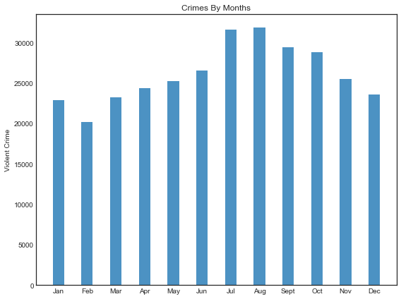

```python
crime_numbers = train_df.groupby(['Month'])['ViolentCrime'].count()
month_nms = ['Jan','Feb','Mar','Apr','May','Jun','Jul','Aug','Sept','Oct','Nov','Dec']
crime_counts = [0,0,0,0,0,0,0,0,0,0,0,0]
months = []

# set the months and crime counts
for i, v in crime_numbers.iteritems():
    months.append(month_nms[int(i)-1])
    crime_counts[int(i)-1] = v

y_pos = np.arange(len(month_nms))
plt.rcParams["figure.figsize"] = (8,6)
plt.bar(y_pos, crime_counts, align='center', width=0.4, alpha=0.8)
plt.xticks(y_pos, month_nms)
plt.ylabel('Violent Crime')
plt.title('Crimes By Months')

#plt.show()
plt.tight_layout()
```

Observations: It does look like the months of June, July, Aug, Sept, Oct have the highest crime rates confirming that there is indeed higher crimes in Summer months

Let's see if the crime numbers vary by Day Of Week

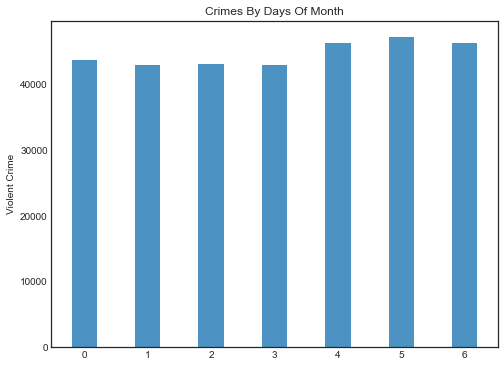

```python
crime_numbers = train_df.groupby(['Dayofweek'])['ViolentCrime'].count()
days_nms = ['Sun','Mon','Tue','Wed','Thu','Fri','Sat']
crime_counts = [0,0,0,0,0,0,0]
days = []

days_of_month = []
crime_counts_by_day = []
for i, v in crime_numbers.iteritems():
    days_of_month.append(int(i))
    crime_counts_by_day.append(v)

y_pos = np.arange(len(days_of_month))

plt.rcParams["figure.figsize"] = (8,6)
plt.bar(y_pos, crime_counts_by_day, align='center',  width=0.4, alpha=0.8)
plt.xticks(y_pos, days_of_month)
plt.ylabel('Violent Crime')
plt.title('Crimes By Days Of Month')

plt.show()
```

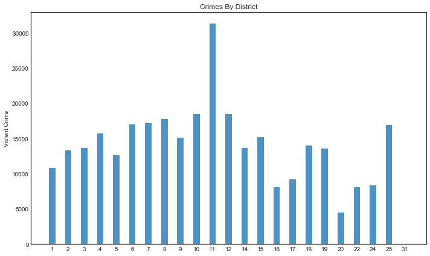

```python
beat_mean_values = train_df.groupby(['District'])['ViolentCrime'].count()

beats = []
crime_counts_by_beat = []
for i, v in beat_mean_values.iteritems():
    beats.append(int(i))
    crime_counts_by_beat.append(v)

y_pos = np.arange(len(beats))

plt.rcParams["figure.figsize"] = (10,6)
plt.bar(y_pos, crime_counts_by_beat, align='center',  width=0.4, alpha=0.8)
plt.xticks(y_pos, beats)
plt.ylabel('Violent Crime')
plt.title('Crimes By District')

#plt.show()
plt.tight_layout()
```

Each district is subdivided into many beats. Lets see the relationship between beats and crime

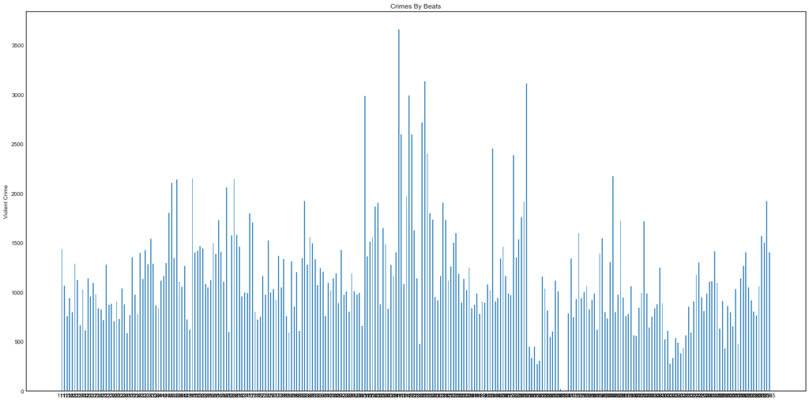

```python
beat_mean_values = train_df.groupby(['Beat'])['ViolentCrime'].count()

beats = []
crime_counts_by_beat = []
for i, v in beat_mean_values.iteritems():
    beats.append(int(i))
    crime_counts_by_beat.append(v)

y_pos = np.arange(len(beats))

plt.rcParams["figure.figsize"] = (20,10)
plt.bar(y_pos, crime_counts_by_beat, align='center',  width=0.4, alpha=0.8)
plt.xticks(y_pos, beats)
plt.ylabel('Violent Crime')
plt.title('Crimes By Beats')

#plt.show()
plt.tight_layout()
```

As shown in the above 2 plots, there is a relationship between crime and location

```python
train_df.dropna()
train_df.info()
```

```
<class 'pandas.core.frame.DataFrame'>
Int64Index: 312923 entries, 164 to 1048572
Data columns (total 19 columns):
Block                   312923 non-null object
Location Description    312923 non-null object
Beat                    312923 non-null int64
District                312923 non-null float64
Ward                    312923 non-null float64
Community Area          312923 non-null float64
X Coordinate            312923 non-null float64
Y Coordinate            312923 non-null float64
Year                    312923 non-null int64
Latitude                312923 non-null float64
Longitude               312923 non-null float64
Community Areas         312923 non-null float64
Census Tracts           312923 non-null float64
Wards                   312923 non-null float64
Police Districts        312923 non-null float64
Police Beats            312923 non-null float64
ViolentCrime            312923 non-null int64
Month                   312923 non-null object
Dayofweek               312923 non-null object
dtypes: float64(12), int64(3), object(4)
memory usage: 47.7+ MB
```

Create the target labels for the data

```python
major_crime = (train_df['ViolentCrime']).apply(lambda x: 1 if (int(x) > 0) else 0)
```

```python
train_df.head()
```

|  | Block | Location Description | Beat | District | Ward | Community Area | X Coordinate | Y Coordinate | Year | Latitude | Longitude | Community Areas | Census Tracts | Wards | Police Districts | Police Beats | ViolentCrime | Month | Dayofweek |
| --- | --- | --- | --- | --- | --- | --- | --- | --- | --- | --- | --- | --- | --- | --- | --- | --- | --- | --- | --- |
| 164 | 080XX S EMERALD AVE | STREET | 621 | 6.0 | 21.0 | 71.0 | 1172697.0 | 1851644.0 | 2019 | 41.748345 | -87.642752 | 70.0 | 529.0 | 13.0 | 20.0 | 229.0 | 1 | 5 | 2 |
| 1236 | 072XX S CLAREMONT AVE | SIDEWALK | 832 | 8.0 | 18.0 | 66.0 | 1161987.0 | 1856698.0 | 2019 | 41.762443 | -87.681857 | 64.0 | 333.0 | 30.0 | 13.0 | 207.0 | 1 | 5 | 1 |
| 1237 | 043XX W FERDINAND ST | STREET | 1111 | 11.0 | 28.0 | 23.0 | 1147367.0 | 1902977.0 | 2019 | 41.889730 | -87.734260 | 24.0 | 99.0 | 23.0 | 16.0 | 68.0 | 0 | 5 | 1 |
| 1282 | 052XX S PULASKI RD | SIDEWALK | 815 | 8.0 | 23.0 | 62.0 | 1150591.0 | 1869514.0 | 2019 | 41.797841 | -87.723293 | 60.0 | 793.0 | 6.0 | 13.0 | 129.0 | 0 | 5 | 1 |
| 1284 | 010XX N MONTICELLO AVE | SIDEWALK | 1112 | 11.0 | 27.0 | 23.0 | 1151857.0 | 1906636.0 | 2019 | 41.899684 | -87.717674 | 24.0 | 456.0 | 46.0 | 16.0 | 66.0 | 0 | 5 | 1 |

# Data Preprocessing

### Convert Lat/Long into Clusters

The districts, beats, police beats, wards etc. are all good way to represent locations, but they are all discrete and we cannot use them to calculate distance for algorithms such as KNN. Latitude and Longitude are very good indicators to figure out the location, but we cannot just calculate distance using them directly.

```python
lat = train_df['Latitude']
long = train_df['Longitude']

reduced_data = pd.concat([lat,long], axis=1)
reduced_data = reduced_data.dropna()

from sklearn.mixture import GaussianMixture
from sklearn.metrics import silhouette_score

for num_of_clusters in [25]:
    clusterer = GaussianMixture(n_components = num_of_clusters, random_state = 17)
    clusterer.fit(reduced_data)
    # TODO: Predict the cluster for each data point
    reduced_data['preds'] = clusterer.predict(reduced_data)

    # TODO: Find the cluster centers
    centers = clusterer.means_

    # TODO: Predict the cluster for each transformed sample data point
    #sample_preds = clusterer.predict(pca_samples)

    from sklearn.metrics import silhouette_score

    # TODO: Calculate the mean silhouette coefficient for the number of clusters chosen
    #score = silhouette_score(reduced_data,  reduced_data['preds'])

    #print ("The score for {} clusters is {}".format(num_of_clusters, score))

train_df['Cluster'] = reduced_data['preds']
train_df = train_df.drop(['Latitude', 'Longitude'], axis=1)
train_df.head()
```

|  | Block | Location Description | Beat | District | Ward | Community Area | X Coordinate | Y Coordinate | Year | Community Areas | Census Tracts | Wards | Police Districts | Police Beats | ViolentCrime | Month | Dayofweek | Cluster |
| --- | --- | --- | --- | --- | --- | --- | --- | --- | --- | --- | --- | --- | --- | --- | --- | --- | --- | --- |
| 164 | 080XX S EMERALD AVE | STREET | 621 | 6.0 | 21.0 | 71.0 | 1172697.0 | 1851644.0 | 2019 | 70.0 | 529.0 | 13.0 | 20.0 | 229.0 | 1 | 5 | 2 | 6 |
| 1236 | 072XX S CLAREMONT AVE | SIDEWALK | 832 | 8.0 | 18.0 | 66.0 | 1161987.0 | 1856698.0 | 2019 | 64.0 | 333.0 | 30.0 | 13.0 | 207.0 | 1 | 5 | 1 | 13 |
| 1237 | 043XX W FERDINAND ST | STREET | 1111 | 11.0 | 28.0 | 23.0 | 1147367.0 | 1902977.0 | 2019 | 24.0 | 99.0 | 23.0 | 16.0 | 68.0 | 0 | 5 | 1 | 20 |
| 1282 | 052XX S PULASKI RD | SIDEWALK | 815 | 8.0 | 23.0 | 62.0 | 1150591.0 | 1869514.0 | 2019 | 60.0 | 793.0 | 6.0 | 13.0 | 129.0 | 0 | 5 | 1 | 3 |
| 1284 | 010XX N MONTICELLO AVE | SIDEWALK | 1112 | 11.0 | 27.0 | 23.0 | 1151857.0 | 1906636.0 | 2019 | 24.0 | 456.0 | 46.0 | 16.0 | 66.0 | 0 | 5 | 1 | 8 |

Now lets plot the crimes using the clusters

```python
import numpy as np
import pandas as pd
import matplotlib.pyplot as plt
import seaborn as sns
sns.set_style('white')
%matplotlib inline

# sklean import
from sklearn.base import BaseEstimator
from sklearn.base import TransformerMixin
from sklearn.preprocessing import MinMaxScaler
from sklearn.pipeline import make_pipeline

from sklearn.linear_model import LogisticRegression
from sklearn.neighbors import KNeighborsClassifier
from sklearn.tree import DecisionTreeClassifier
from sklearn.svm import SVC
from sklearn.ensemble import RandomForestClassifier

from sklearn.cross_validation import KFold
from sklearn.cross_validation import cross_val_score
from sklearn.cross_validation import train_test_split
from sklearn.metrics import make_scorer
from sklearn.metrics import fbeta_score
from sklearn.metrics import accuracy_score
from sklearn.metrics import confusion_matrix
from sklearn.grid_search import GridSearchCV
```

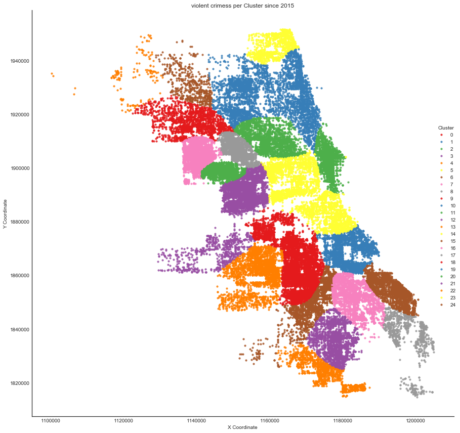

```python
def plot_crime_incidents(crime_data, incident_type, criteria):
    crime_data = crime_data.loc[(crime_data['X Coordinate']!=0)]
    sns.lmplot('X Coordinate',
           'Y Coordinate',
           data=crime_data[:],
           fit_reg=False,
           hue=criteria,
           palette='Set1',
           size=12,
           ci=2,
           scatter_kws={"marker": "D",
                            "s": 10})

    ax = plt.gca()
    title = incident_type.lower() + 's per ' + criteria + ' since 2015'
    ax.set_title(title)
    plt.tight_layout()

crime_data_to_plot = train_df.loc[(train_df['ViolentCrime'] == 1)]

plot_crime_incidents(crime_data_to_plot, 'Violent Crimes', 'Cluster')
train_df = train_df.drop(['ViolentCrime'], axis=1)
```

Now lets plot the crimes to districts

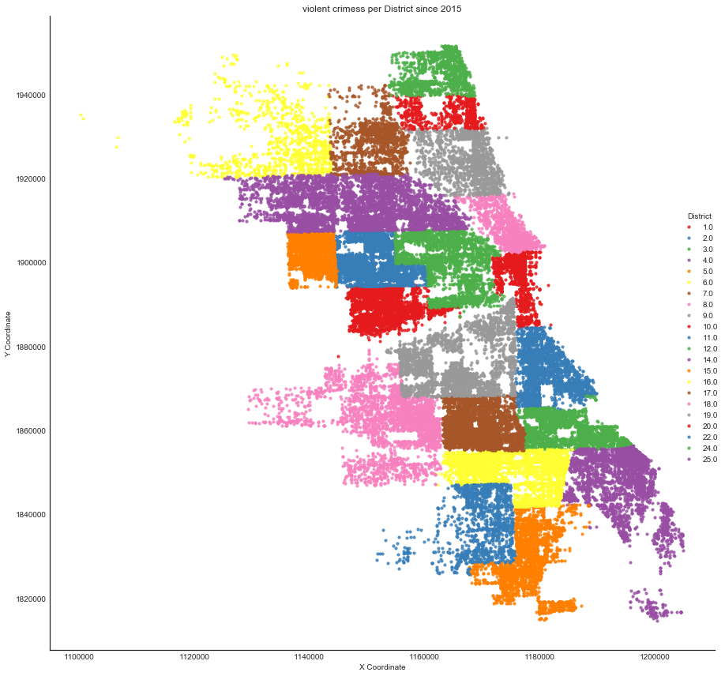

```python
plot_crime_incidents(crime_data_to_plot, 'Violent Crimes', 'District')
```